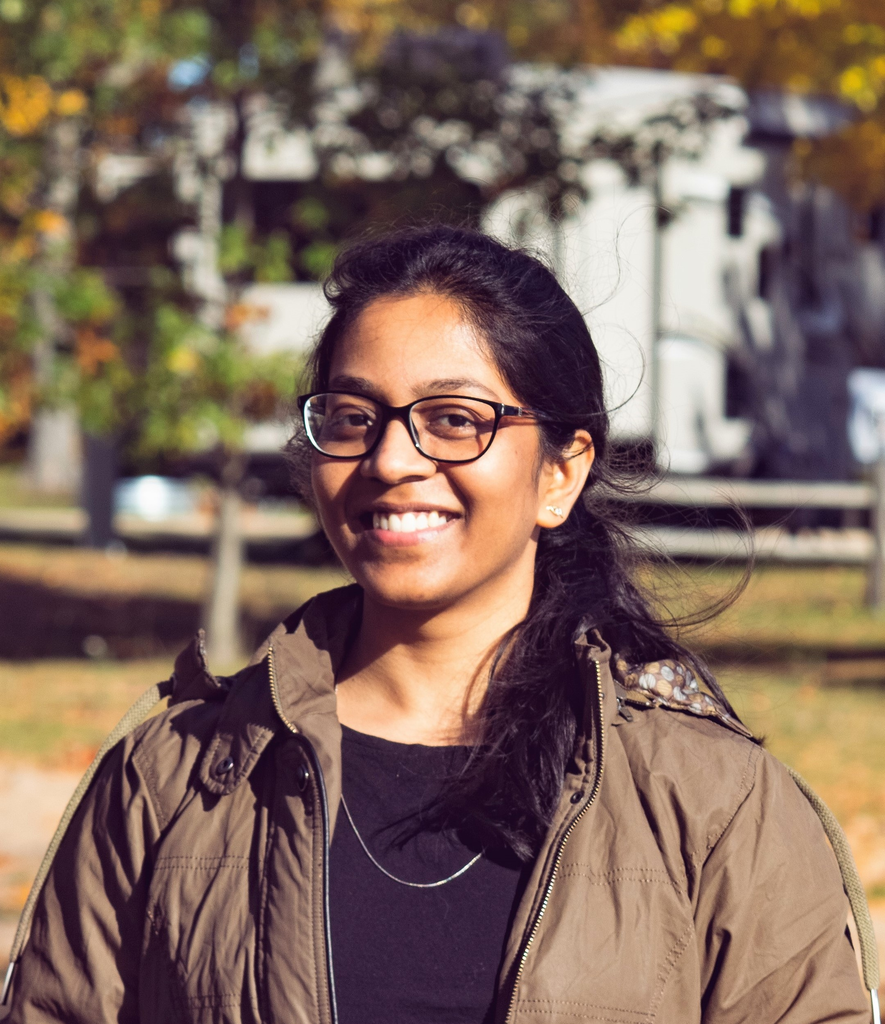

# Manisha Barse

#### About Me

I am currently working as a Research Assistant at Lieber Institute of Brian Development in Data Science Team headed by Leonardo Collado-Torres. I hold dual master’s degrees in Bioinformatics and Materials Engineering from UIC, where I focused on bioinformatics analyses, particularly with protein structure prediction, scRNA-seq and scATAC-seq data. I’ve utilized tools like Seurat, Signac in R, and Scanpy in Python for data analysis. Currently I am learning about spatial transcriptomics and building computational pipelines.

#### Education

**University of Illinois Chicago** | Chicago, IL.  
M.S. in Materials Engineering | 2022 - 2023  
M.S. in Bioinformatics | 2019 - 2022

**ABV Indian Institute of Information Technology & Management** | Gwalior, India.  
M.Tech in VLSI Design | 2016 - 2018

#### Experience

**Lieber Institute of Brain Development** | Research Assistant - Data Science | August 2024 - Present

**Computational Materials Research Lab, UIC** | Research Assistant | August 2022 - August 2024

**Data Glacier** | Data Science Intern | January 2024 - May 2024

**University of Illinois Chicago** | Teaching Assistant | January 2021 - July 2023

**Molecular & Systems Computational Bioengineering Lab, UIC** | Research Assistant | August 2019 - July 2022

#### Publications

[3D-BMPP: 3D Beta-barrel Membrane Protein Predictor](https://pubmed.ncbi.nlm.nih.gov/36959455/) Tian W, Lin M, Tang K, Barse M, Naveed H, and Liang J. (March 2023).  
[Morse Code- A Security Enhancer](https://www.ijsr.net/get_count.php?paper_id=ART20161152) Barse M, Manuel R. (2016).  
[Characterization of Accelerometer For Defence Application](https://europub.co.uk/articles/characterization-of-accelerometer-for-defense-application-A-28418) Manuel R, Barse M, Aware A. (2016).  
[Evolution of VLAN](https://repo.ijiert.org/index.php/ijiert/article/view/692) Barse M, Manuel R. (2015).

#### Conference Poster Presentations

Modelling Long Loops of Membrane Proteins using Pretzel | 65th Biophysical Society Annual Meeting | Feb 2021.  
[First Principle investigation of diabetes biomarkers effect on carbon nanotube based devices](https://inis.iaea.org/search/search.aspx?orig_q=RN:52097408) | First International. Conference on Advances in Nanomaterials and Devices for Energy and Environment | Jan 2019.